# Word Learning - Psych Science

Kimberly A. Brink

10/25/2017

“Word Learning” is a study that assesses whether children will selectively trust a robot that provides accurate information compared to a robot that provides inaccurate information. Children watch two robots name a series of familiar objects, where one robot always names the object correctly and the other robot always incorrectly names the robot. The two robots are distingushed by their colors.

# Word Learning 1: Experimental Condition

## Method

### Demographics

There are 67 participants.

The average age of the sample is 3.55 years.

The standard deviation age of the sample is 0.27 years.

The minimum age of the sample is 3.03 years.

The maximum age of the sample is 4 years.

There are 36 females in the sample.

Power analyses indicate that N = 33.37 is sufficient to achieve .80 statistical power with a moderate effect size of .5 and signficance level of p = .05 (Cohen, 1988).

### Exclusions

1 participant was excluded for being a non-native english speaker.

6 participants asked to end early

1 participant had parent interference.

### Reduced Demographics

There are now 59 participants.

The average age of the sample is 3.56 years.

The standard deviation age of the sample is 0.27 years.

The minimum age of the sample is 3.03 years.

The maximum age of the sample is 4 years.

There are 33 females in the sample.

| African-American | Asian/Pacific-Islander | Bi-Racial | Caucasian |
| --- | --- | --- | --- |
| 0 | 1 | 8 | 50 |

Distribution by Order of Presentation

| A | B | C | D |
| --- | --- | --- | --- |
| 14 | 13 | 15 | 17 |

### Performance during accuracy trials

Participant Count by Number of Trials Correct

| 2 | 3 | 4 |
| --- | --- | --- |
| 1 | 5 | 53 |

Distribution by Order of Presentation after removing for familiarization

| A | B | C | D |
| --- | --- | --- | --- |
| 14 | 13 | 12 | 14 |

### Final Demographics

Now there are 53 participants after removing for familiarization errors.

The average age of the sample is 3.56 years.

The standard deviation age of the sample is 0.27 years.

The minimum age of the sample is 3.03 years.

The maximum age of the sample is 4 years.

There are 32 females in the sample.

## Results

### Comparisons with chance for three test questions.

| Question | Proportion | t.df. | p | X95.CI |
| --- | --- | --- | --- | --- |
| Explicit judgment | 0.96 (0.03) | t(52)=17.49 | 0 | 0.91,1.02 |
| Ask | 0.63 (0.04) | t(52)=3.44 | 0.0012 | 0.55,0.7 |
| Endorse | 0.68 (0.04) | t(51)=4.11 | 0.0001 | 0.59,0.77 |

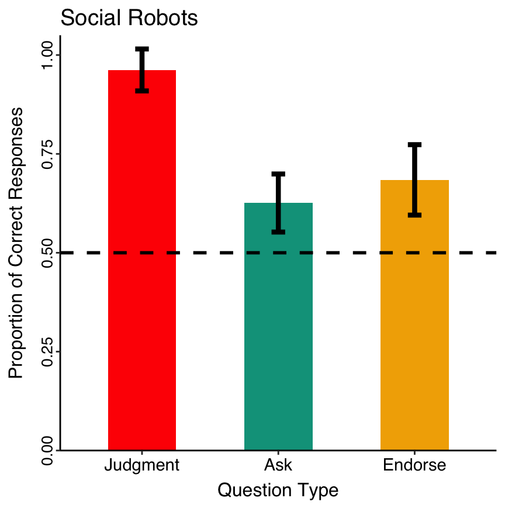

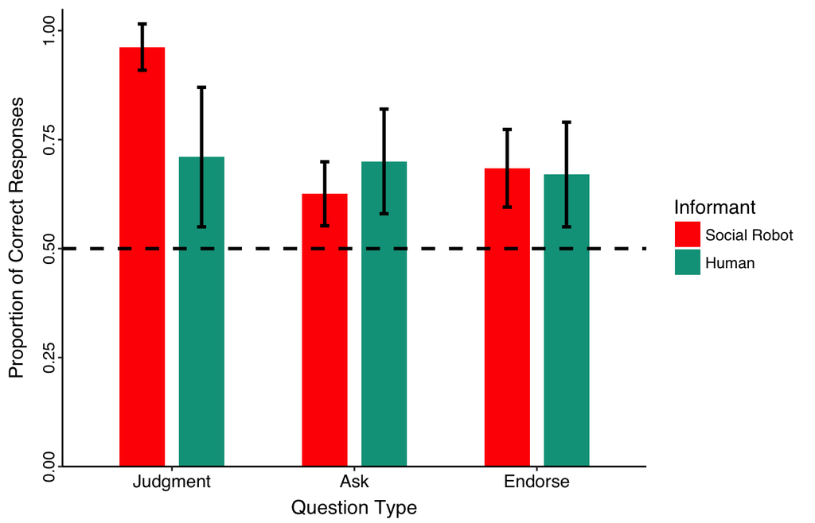

Children’s total performance scores ranged from 0 to 1 (M = 0.65, SD = 0.25)

### Comparisons with chance for three test questions for subset that answered first EJ question correctly.

| Question | Proportion | t.df. | p | X95.CI |
| --- | --- | --- | --- | --- |
| Ask | 0.62 (0.04) | t(50)=3.12 | 0.003 | 0.54,0.69 |
| Endorse | 0.69 (0.04) | t(49)=4.14 | 0.0001 | 0.6,0.78 |

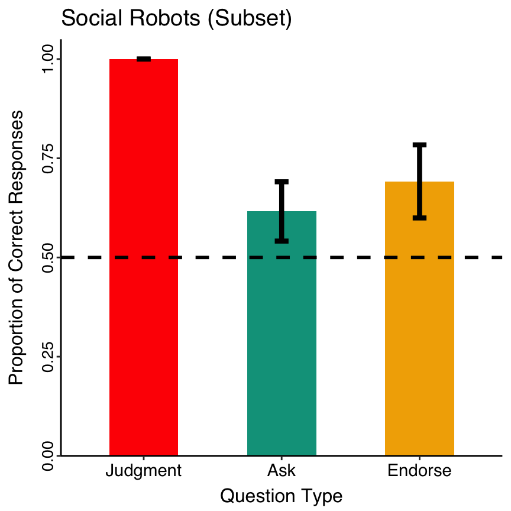

51 out of 53 children answered the first explicit judgment question correctly.

### Regression Analyses

Children’s scores for Agency ranged from 0 to 3 (M = 1.82, SD = 0.91). Scores on average were different from 0, t(47) = 13.82, p = 0.

Children’s scores for Experience ranged from 0 to 3 (M = 1.99, SD = 1.02). Scores on average were different from 0, t(47) = 13.52, p = 0.

```
##
## Call:
## glm(formula = Total ~ ExpIndex.cent + AgIndex.cent + Age.cent +
##     Sex + Order, data = WL1)
##
## Deviance Residuals:
##     Min       1Q   Median       3Q      Max
## -0.3589  -0.1155   0.0252   0.0950   0.3369
##
## Coefficients:
##               Estimate Std. Error t value        Pr(>|t|)
## (Intercept)     0.5990     0.0602    9.95 0.0000000000029 ***
## ExpIndex.cent  -0.0054     0.0290   -0.19          0.8534
## AgIndex.cent    0.0524     0.0296    1.77          0.0845 .
## Age.cent        0.0667     0.0273    2.44          0.0192 *
## SexMale        -0.0826     0.0556   -1.49          0.1453
## OrderB          0.2281     0.0723    3.15          0.0031 **
## OrderC          0.0566     0.0828    0.68          0.4981
## OrderD          0.1206     0.0776    1.55          0.1284
## ---
## Signif. codes:  0 '***' 0.001 '**' 0.01 '*' 0.05 '.' 0.1 ' ' 1
##
## (Dispersion parameter for gaussian family taken to be 0.03023)
##
##     Null deviance: 1.9819  on 46  degrees of freedom
## Residual deviance: 1.1791  on 39  degrees of freedom
##   (6 observations deleted due to missingness)
## AIC: -21.84
##
## Number of Fisher Scoring iterations: 2
```

|  | Estimate | Std. Error | t value | Pr(>\|t\|) |
| --- | --- | --- | --- | --- |
| **(Intercept)** | 0.599 | 0.06019 | 9.951 | 0.000000000002942 |
| **ExpIndex.cent** | -0.0054 | 0.02902 | -0.1861 | 0.8534 |
| **AgIndex.cent** | 0.05244 | 0.02963 | 1.77 | 0.08455 |
| **Age.cent** | 0.06665 | 0.0273 | 2.442 | 0.01925 |
| **SexMale** | -0.08264 | 0.05561 | -1.486 | 0.1453 |
| **OrderB** | 0.2281 | 0.07231 | 3.155 | 0.003091 |
| **OrderC** | 0.05665 | 0.08283 | 0.6839 | 0.4981 |
| **OrderD** | 0.1206 | 0.07765 | 1.554 | 0.1284 |

Fitting linear model: Total ~ ExpIndex.cent + AgIndex.cent + Age.cent + Sex + Order

| Observations | Residual Std. Error | $R^2$ | Adjusted $R^2$ |
| --- | --- | --- | --- |
| 47 | 0.1739 | 0.4051 | 0.2983 |

```
## ExpIndex.cent  AgIndex.cent      Age.cent       SexMale        OrderB
##      -0.02605       0.24958       0.31755      -0.19750            NA
##        OrderC        OrderD
##       0.27331       0.57408
```

```
##
## Call:
## glm(formula = Total ~ AgIndex.cent + Age.cent, data = WL1)
##
## Deviance Residuals:
##     Min       1Q   Median       3Q      Max
## -0.4374  -0.1084  -0.0145   0.1011   0.5149
##
## Coefficients:
##              Estimate Std. Error t value            Pr(>|t|)
## (Intercept)    0.6653     0.0278   23.91 <0.0000000000000002 ***
## AgIndex.cent   0.0509     0.0285    1.78              0.0811 .
## Age.cent       0.0887     0.0287    3.09              0.0035 **
## ---
## Signif. codes:  0 '***' 0.001 '**' 0.01 '*' 0.05 '.' 0.1 ' ' 1
##
## (Dispersion parameter for gaussian family taken to be 0.03714)
##
##     Null deviance: 2.1566  on 47  degrees of freedom
## Residual deviance: 1.6715  on 45  degrees of freedom
##   (5 observations deleted due to missingness)
## AIC: -16.94
##
## Number of Fisher Scoring iterations: 2
```

```
##
## Call:
## glm(formula = Total.red ~ ExpIndex.cent + AgIndex.cent + Age.cent +
##     Sex + Order, data = WL1)
##
## Deviance Residuals:
##     Min       1Q   Median       3Q      Max
## -0.4241  -0.1176   0.0164   0.1097   0.3730
##
## Coefficients:
##               Estimate Std. Error t value      Pr(>|t|)
## (Intercept)    0.55100    0.06772    8.14 0.00000000062 ***
## ExpIndex.cent -0.00761    0.03265   -0.23        0.8170
## AgIndex.cent   0.06930    0.03333    2.08        0.0442 *
## Age.cent       0.07265    0.03071    2.37        0.0230 *
## SexMale       -0.09500    0.06256   -1.52        0.1369
## OrderB         0.27897    0.08135    3.43        0.0014 **
## OrderC         0.05515    0.09318    0.59        0.5573
## OrderD         0.12158    0.08735    1.39        0.1718
## ---
## Signif. codes:  0 '***' 0.001 '**' 0.01 '*' 0.05 '.' 0.1 ' ' 1
##
## (Dispersion parameter for gaussian family taken to be 0.03826)
##
##     Null deviance: 2.5954  on 46  degrees of freedom
## Residual deviance: 1.4921  on 39  degrees of freedom
##   (6 observations deleted due to missingness)
## AIC: -10.77
##
## Number of Fisher Scoring iterations: 2
```

|  | Estimate | Std. Error | t value | Pr(>\|t\|) |
| --- | --- | --- | --- | --- |
| **(Intercept)** | 0.551 | 0.06772 | 8.137 | 0.0000000006219 |
| **ExpIndex.cent** | -0.007608 | 0.03265 | -0.233 | 0.817 |
| **AgIndex.cent** | 0.0693 | 0.03333 | 2.079 | 0.04423 |
| **Age.cent** | 0.07265 | 0.03071 | 2.366 | 0.02305 |
| **SexMale** | -0.095 | 0.06256 | -1.519 | 0.1369 |
| **OrderB** | 0.279 | 0.08135 | 3.429 | 0.001443 |
| **OrderC** | 0.05515 | 0.09318 | 0.5919 | 0.5573 |
| **OrderD** | 0.1216 | 0.08735 | 1.392 | 0.1718 |

Fitting linear model: Total.red ~ ExpIndex.cent + AgIndex.cent + Age.cent + Sex + Order

| Observations | Residual Std. Error | $R^2$ | Adjusted $R^2$ |
| --- | --- | --- | --- |
| 47 | 0.1956 | 0.4251 | 0.3219 |

```
## ExpIndex.cent  AgIndex.cent      Age.cent       SexMale        OrderB
##      -0.03207       0.28820       0.30246      -0.19839            NA
##        OrderC        OrderD
##       0.23253       0.50561
```

```
## ExpIndex.cent  AgIndex.cent      Age.cent       SexMale        OrderB
##      -0.03207       0.28820       0.30246      -0.19839            NA
##        OrderC        OrderD
##       0.23253       0.50561
```

```
##
## Call:
## glm(formula = scale(Total.red) ~ ExpIndex.cent + AgIndex.cent +
##     Age.cent + Sex + Order, data = WL1)
##
## Deviance Residuals:
##     Min       1Q   Median       3Q      Max
## -1.7038  -0.4724   0.0657   0.4405   1.4987
##
## Coefficients:
##               Estimate Std. Error t value Pr(>|t|)
## (Intercept)    -0.3947     0.2720   -1.45   0.1548
## ExpIndex.cent  -0.0306     0.1312   -0.23   0.8170
## AgIndex.cent    0.2784     0.1339    2.08   0.0442 *
## Age.cent        0.2919     0.1234    2.37   0.0230 *
## SexMale        -0.3817     0.2513   -1.52   0.1369
## OrderB          1.1207     0.3268    3.43   0.0014 **
## OrderC          0.2216     0.3744    0.59   0.5573
## OrderD          0.4884     0.3509    1.39   0.1718
## ---
## Signif. codes:  0 '***' 0.001 '**' 0.01 '*' 0.05 '.' 0.1 ' ' 1
##
## (Dispersion parameter for gaussian family taken to be 0.6175)
##
##     Null deviance: 41.889  on 46  degrees of freedom
## Residual deviance: 24.083  on 39  degrees of freedom
##   (6 observations deleted due to missingness)
## AIC: 120
##
## Number of Fisher Scoring iterations: 2
```

```
##
## Call:
## glm(formula = Total.red ~ AgIndex.cent + Age.cent + Order, data = WL1)
##
## Deviance Residuals:
##     Min       1Q   Median       3Q      Max
## -0.3782  -0.1041  -0.0003   0.1221   0.4268
##
## Coefficients:
##              Estimate Std. Error t value      Pr(>|t|)
## (Intercept)    0.5039     0.0604    8.35 0.00000000019 ***
## AgIndex.cent   0.0671     0.0314    2.14        0.0384 *
## Age.cent       0.0758     0.0311    2.44        0.0190 *
## OrderB         0.2702     0.0831    3.25        0.0023 **
## OrderC         0.0539     0.0885    0.61        0.5455
## OrderD         0.1356     0.0853    1.59        0.1197
## ---
## Signif. codes:  0 '***' 0.001 '**' 0.01 '*' 0.05 '.' 0.1 ' ' 1
##
## (Dispersion parameter for gaussian family taken to be 0.04064)
##
##     Null deviance: 2.8309  on 47  degrees of freedom
## Residual deviance: 1.7071  on 42  degrees of freedom
##   (5 observations deleted due to missingness)
## AIC: -9.93
##
## Number of Fisher Scoring iterations: 2
```

```
##
##  Pearson's product-moment correlation
##
## data:  WL1$Total.red and WL1$AgIndex
## t = 1.9, df = 46, p-value = 0.07
## alternative hypothesis: true correlation is not equal to 0
## 95 percent confidence interval:
##  -0.01914  0.51183
## sample estimates:
##    cor
## 0.2664
```

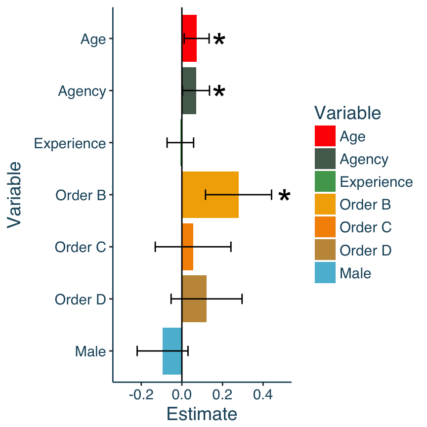

```
## $fill
## [1] FALSE
##
## attr(,"class")
## [1] "guides"
```

### Correlation with Agency

```
##
##  Pearson's product-moment correlation
##
## data:  WL1$Total and WL1$AgIndex
## t = 1.7, df = 46, p-value = 0.09
## alternative hypothesis: true correlation is not equal to 0
## 95 percent confidence interval:
##  -0.0404  0.4960
## sample estimates:
##    cor
## 0.2466
```

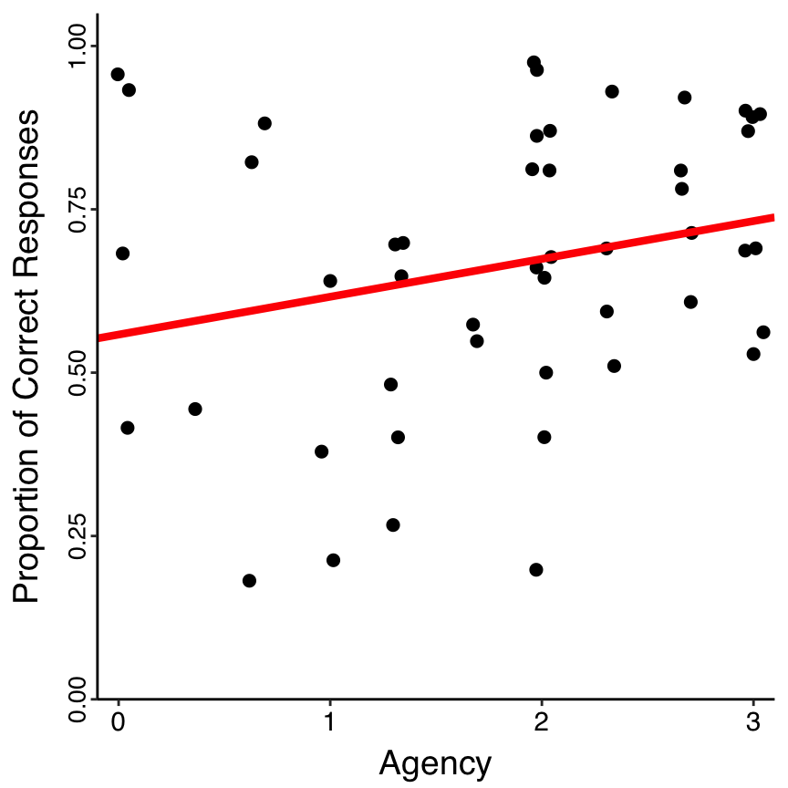

# Word Learning 2: Control Study

## Method

### Demographics

There are 50 participants.

The average age of the sample is 3.46 years.

The standard devation of the age of the sample is 0.33 years.

The minimum age of the sample is 3.01 years.

The maximum age of the sample is 4 years.

There are 24 females in the sample.

### Exclusions

1 participant had parent interference.

1 participant was excluded for being a non-native english speaker.

2 participants asked to end early

### Reduced Demographics

There are now 46 participants.

The average age of the sample is 3.47 years.

The standard devaition of the age of the sample is 0.34 years.

The minimum age of the sample is 3.01 years.

The maximum age of the sample is 4 years.

There are 22 females in the sample.

Table continues below

| African-American | Asian and White | Asian/Pacific-Islander | Bi-Racial |
| --- | --- | --- | --- |
| 1 | 1 | 1 | 8 |

| Caucasian | White | Whtie | NA’s |
| --- | --- | --- | --- |
| 30 | 2 | 1 | 2 |

Distribution by Order of Presentation

| A | B | C | D |
| --- | --- | --- | --- |
| 13 | 14 | 10 | 9 |

## Performance during accuracy trials

Participant Count by Number of Trials Correct

| 1 | 2 | 3 | 4 |
| --- | --- | --- | --- |
| 2 | 6 | 4 | 34 |

Distribution by Order of Presentation after removing for familiarization

| A | B | C | D |
| --- | --- | --- | --- |
| 10 | 9 | 7 | 8 |

### Final Demographics

Now there are 34 participants after removing for familiarization errors.

There are 34 participants.

The average age of the sample is 3.46 years.

The standard devaition of the age of the sample is 0.34 years.

The minimum age of the sample is 3.01 years.

The maximum age of the sample is 3.99 years.

There are 17 females in the sample.

## Results

### Comparisons with chance for three test questions.

| Question | Proportion | t.df. | p | X95.CI |
| --- | --- | --- | --- | --- |
| Explicit judgment | 0.74 (0.07) | t(33)=3.06 | 0.0043 | 0.58,0.89 |
| Ask | 0.48 (0.05) | t(33)=-0.4 | 0.6886 | 0.38,0.58 |
| Endorse | 0.54 (0.05) | t(33)=0.88 | 0.3867 | 0.45,0.64 |

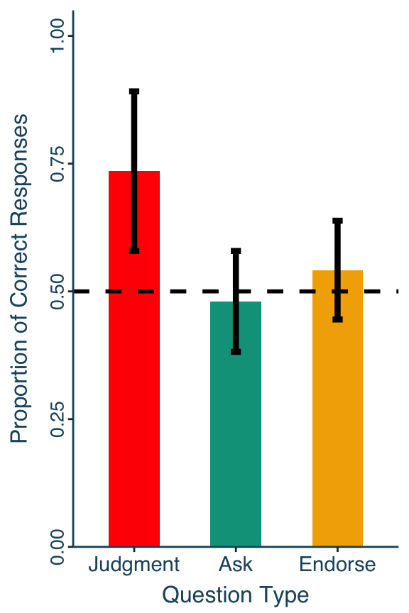

Children’s total performance scores ranged from 0.125 to 0.875 (M = 0.51, SD = 0.21)

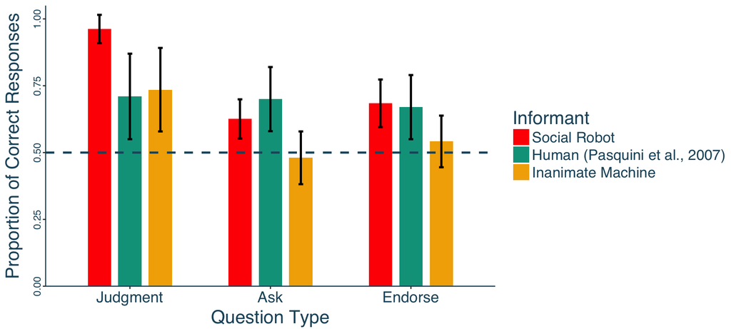

### Comparisons with chance for three test questions for subset that answered first EJ question correctly.

| Question | Proportion | t.df. | p | X95.CI |
| --- | --- | --- | --- | --- |
| Ask | 0.46 (0.04) | t(24)=-0.61 | 0.5489 | 0.34,0.59 |
| Endorse | 0.56 (0.04) | t(24)=1.09 | 0.2885 | 0.45,0.66 |

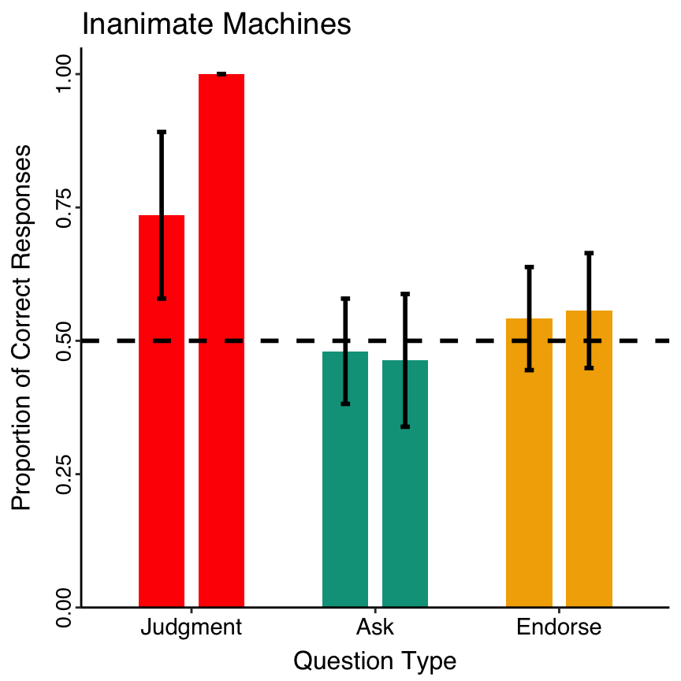

25 out of 34 children answered the first explicit judgment question correctly.

Children were still at chance for Ask, , t(24) = -0.61, p = 0.5489; and Endorsement questions, t(24) = 1.09, p = 0.2885.

### Regression Analyses

Children’s scores for Agency ranged from 0 to 3 (M = 1.69, SD = 0.96). Scores on average were different from 0, t(29) = 9.65, p = 0.

Children’s scores for Experience ranged from 0 to 3 (M = 1.71, SD = 1.05). Scores on average were different from 0, t(29) = 8.96, p = 0.

```
##
## Call:
## glm(formula = Total ~ ExpIndex.cent + AgIndex.cent + Age.cent +
##     Sex + Order, data = WL2)
##
## Deviance Residuals:
##     Min       1Q   Median       3Q      Max
## -0.2796  -0.1358  -0.0185   0.1020   0.3451
##
## Coefficients:
##               Estimate Std. Error t value  Pr(>|t|)
## (Intercept)     0.8132     0.1261    6.45 0.0000022 ***
## ExpIndex.cent  -0.0963     0.0423   -2.28     0.033 *
## AgIndex.cent    0.0618     0.0429    1.44     0.165
## Age.cent        0.7506     0.4523    1.66     0.112
## SexMale        -0.0803     0.0713   -1.13     0.273
## OrderB          0.0526     0.0997    0.53     0.603
## OrderC         -0.1633     0.0992   -1.65     0.114
## OrderD         -0.1464     0.0939   -1.56     0.134
## ---
## Signif. codes:  0 '***' 0.001 '**' 0.01 '*' 0.05 '.' 0.1 ' ' 1
##
## (Dispersion parameter for gaussian family taken to be 0.03211)
##
##     Null deviance: 1.1111  on 28  degrees of freedom
## Residual deviance: 0.6744  on 21  degrees of freedom
##   (5 observations deleted due to missingness)
## AIC: -8.777
##
## Number of Fisher Scoring iterations: 2
```

|  | Estimate | Std. Error | t value | Pr(>\|t\|) |
| --- | --- | --- | --- | --- |
| **(Intercept)** | 0.8132 | 0.1261 | 6.45 | 0.000002158 |
| **ExpIndex.cent** | -0.09626 | 0.0423 | -2.275 | 0.03348 |
| **AgIndex.cent** | 0.0618 | 0.04294 | 1.439 | 0.1649 |
| **Age.cent** | 0.7506 | 0.4523 | 1.66 | 0.1118 |
| **SexMale** | -0.08031 | 0.07127 | -1.127 | 0.2725 |
| **OrderB** | 0.05264 | 0.0997 | 0.528 | 0.6031 |
| **OrderC** | -0.1633 | 0.09916 | -1.647 | 0.1144 |
| **OrderD** | -0.1464 | 0.09392 | -1.559 | 0.134 |

Fitting linear model: Total ~ ExpIndex.cent + AgIndex.cent + Age.cent + Sex + Order

| Observations | Residual Std. Error | $R^2$ | Adjusted $R^2$ |
| --- | --- | --- | --- |
| 29 | 0.1792 | 0.3931 | 0.1907 |

```
## ExpIndex.cent  AgIndex.cent      Age.cent       SexMale        OrderB
##       -0.4707        0.3080        0.2884       -0.2050            NA
##        OrderC        OrderD
##       -0.7987       -0.7297
```

```
##
## Call:
## glm(formula = Total ~ AgIndex.cent + Age.cent, data = WL2)
##
## Deviance Residuals:
##     Min       1Q   Median       3Q      Max
## -0.2501  -0.1633  -0.0659   0.2019   0.2950
##
## Coefficients:
##              Estimate Std. Error t value   Pr(>|t|)
## (Intercept)    0.7146     0.1106    6.46 0.00000063 ***
## AgIndex.cent  -0.0107     0.0357   -0.30      0.767
## Age.cent       0.8285     0.4759    1.74      0.093 .
## ---
## Signif. codes:  0 '***' 0.001 '**' 0.01 '*' 0.05 '.' 0.1 ' ' 1
##
## (Dispersion parameter for gaussian family taken to be 0.03659)
##
##     Null deviance: 1.11176  on 29  degrees of freedom
## Residual deviance: 0.98782  on 27  degrees of freedom
##   (4 observations deleted due to missingness)
## AIC: -9.267
##
## Number of Fisher Scoring iterations: 2
```

```
##
## Call:
## glm(formula = Total.red ~ ExpIndex.cent + AgIndex.cent + Age.cent +
##     Sex + Order, data = WL2)
##
## Deviance Residuals:
##     Min       1Q   Median       3Q      Max
## -0.2742  -0.1372  -0.0366   0.1267   0.4185
##
## Coefficients:
##               Estimate Std. Error t value Pr(>|t|)
## (Intercept)     0.7945     0.1424    5.58 0.000015 ***
## ExpIndex.cent  -0.0783     0.0478   -1.64     0.12
## AgIndex.cent    0.0682     0.0485    1.41     0.17
## Age.cent        0.8195     0.5107    1.60     0.12
## SexMale        -0.0608     0.0805   -0.76     0.46
## OrderB          0.0752     0.1126    0.67     0.51
## OrderC         -0.1685     0.1120   -1.50     0.15
## OrderD         -0.1778     0.1061   -1.68     0.11
## ---
## Signif. codes:  0 '***' 0.001 '**' 0.01 '*' 0.05 '.' 0.1 ' ' 1
##
## (Dispersion parameter for gaussian family taken to be 0.04096)
##
##     Null deviance: 1.30882  on 28  degrees of freedom
## Residual deviance: 0.86006  on 21  degrees of freedom
##   (5 observations deleted due to missingness)
## AIC: -1.725
##
## Number of Fisher Scoring iterations: 2
```

|  | Estimate | Std. Error | t value | Pr(>\|t\|) |
| --- | --- | --- | --- | --- |
| **(Intercept)** | 0.7945 | 0.1424 | 5.581 | 0.00001543 |
| **ExpIndex.cent** | -0.07828 | 0.04777 | -1.639 | 0.1162 |
| **AgIndex.cent** | 0.06817 | 0.0485 | 1.406 | 0.1745 |
| **Age.cent** | 0.8195 | 0.5107 | 1.605 | 0.1235 |
| **SexMale** | -0.06079 | 0.08049 | -0.7552 | 0.4585 |
| **OrderB** | 0.07519 | 0.1126 | 0.6678 | 0.5116 |
| **OrderC** | -0.1685 | 0.112 | -1.505 | 0.1473 |
| **OrderD** | -0.1778 | 0.1061 | -1.676 | 0.1085 |

Fitting linear model: Total.red ~ ExpIndex.cent + AgIndex.cent + Age.cent + Sex + Order

| Observations | Residual Std. Error | $R^2$ | Adjusted $R^2$ |
| --- | --- | --- | --- |
| 29 | 0.2024 | 0.3429 | 0.1238 |

```
## ExpIndex.cent  AgIndex.cent      Age.cent       SexMale        OrderB
##       -0.3527        0.3131        0.2901       -0.1430            NA
##        OrderC        OrderD
##       -0.7592       -0.8165
```

```
##
## Call:
## glm(formula = Total.red ~ AgIndex.cent + Age.cent, data = WL2)
##
## Deviance Residuals:
##     Min       1Q   Median       3Q      Max
## -0.3042  -0.1449  -0.0562   0.2066   0.3333
##
## Coefficients:
##              Estimate Std. Error t value  Pr(>|t|)
## (Intercept)   0.70243    0.12050    5.83 0.0000033 ***
## AgIndex.cent -0.00332    0.03887   -0.09     0.933
## Age.cent      0.89535    0.51864    1.73     0.096 .
## ---
## Signif. codes:  0 '***' 0.001 '**' 0.01 '*' 0.05 '.' 0.1 ' ' 1
##
## (Dispersion parameter for gaussian family taken to be 0.04345)
##
##     Null deviance: 1.3088  on 29  degrees of freedom
## Residual deviance: 1.1732  on 27  degrees of freedom
##   (4 observations deleted due to missingness)
## AIC: -4.109
##
## Number of Fisher Scoring iterations: 2
```

```
## ExpIndex.cent  AgIndex.cent      Age.cent       SexMale        OrderB
##       -0.3527        0.3131        0.2901       -0.1430            NA
##        OrderC        OrderD
##       -0.7592       -0.8165
```

```
##
## Call:
## glm(formula = scale(Total.red) ~ ExpIndex.cent + AgIndex.cent +
##     Age.cent + Sex + Order, data = WL2)
##
## Deviance Residuals:
##    Min      1Q  Median      3Q     Max
## -1.315  -0.658  -0.175   0.608   2.006
##
## Coefficients:
##               Estimate Std. Error t value Pr(>|t|)
## (Intercept)      1.341      0.683    1.96    0.063 .
## ExpIndex.cent   -0.375      0.229   -1.64    0.116
## AgIndex.cent     0.327      0.233    1.41    0.174
## Age.cent         3.929      2.449    1.60    0.124
## SexMale         -0.291      0.386   -0.76    0.458
## OrderB           0.360      0.540    0.67    0.512
## OrderC          -0.808      0.537   -1.50    0.147
## OrderD          -0.852      0.509   -1.68    0.109
## ---
## Signif. codes:  0 '***' 0.001 '**' 0.01 '*' 0.05 '.' 0.1 ' ' 1
##
## (Dispersion parameter for gaussian family taken to be 0.9415)
##
##     Null deviance: 30.087  on 28  degrees of freedom
## Residual deviance: 19.771  on 21  degrees of freedom
##   (5 observations deleted due to missingness)
## AIC: 89.19
##
## Number of Fisher Scoring iterations: 2
```

```
##
## Call:
## glm(formula = Total.red ~ AgIndex.cent + Age.cent + Order, data = WL2)
##
## Deviance Residuals:
##     Min       1Q   Median       3Q      Max
## -0.3195  -0.1440  -0.0387   0.1771   0.3058
##
## Coefficients:
##              Estimate Std. Error t value Pr(>|t|)
## (Intercept)    0.7342     0.1351    5.43 0.000014 ***
## AgIndex.cent   0.0285     0.0419    0.68     0.50
## Age.cent       0.8604     0.5125    1.68     0.11
## OrderB         0.0833     0.1135    0.73     0.47
## OrderC        -0.0936     0.1035   -0.90     0.37
## OrderD        -0.1341     0.1011   -1.33     0.20
## ---
## Signif. codes:  0 '***' 0.001 '**' 0.01 '*' 0.05 '.' 0.1 ' ' 1
##
## (Dispersion parameter for gaussian family taken to be 0.04198)
##
##     Null deviance: 1.3088  on 29  degrees of freedom
## Residual deviance: 1.0075  on 24  degrees of freedom
##   (4 observations deleted due to missingness)
## AIC: -2.674
##
## Number of Fisher Scoring iterations: 2
```

```
##
##  Pearson's product-moment correlation
##
## data:  WL2$Total.red and WL2$AgIndex
## t = -0.37, df = 28, p-value = 0.7
## alternative hypothesis: true correlation is not equal to 0
## 95 percent confidence interval:
##  -0.4187  0.2989
## sample estimates:
##      cor
## -0.06883
```

[figure not shown]

### Correlation with Agency

```
##
##  Pearson's product-moment correlation
##
## data:  WL2$Total and WL2$AgIndex
## t = -0.58, df = 28, p-value = 0.6
## alternative hypothesis: true correlation is not equal to 0
## 95 percent confidence interval:
##  -0.4511  0.2621
## sample estimates:
##     cor
## -0.1084
```

[figure not shown]

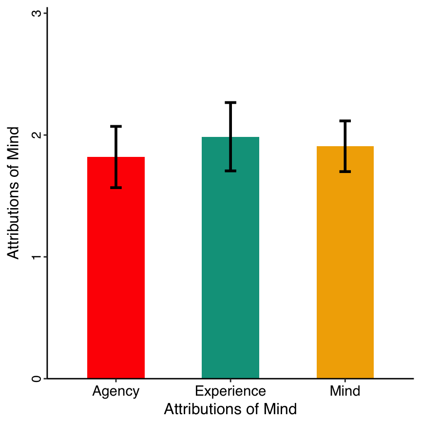

| Factor | Difference | t.df. | p | X95.CI |
| --- | --- | --- | --- | --- |
| Agency | 0.13 | t(59.37)=0.6 | 0.5534 | -0.31,0.57 |
| Experience | 0.28 | t(60.42)=1.14 | 0.2581 | -0.21,0.76 |
| Mind | 0.2 | t(55.69)=1.07 | 0.2895 | -0.18,0.58 |

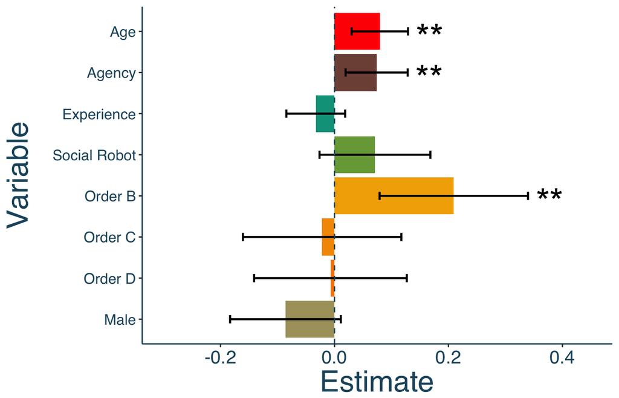